# SEIR with Intervention Assignment

Nzambuli Daniel

2024-02-02

# Task

## Information

**Parameters of Interest:** : Contact Rate (7), Transmission Probability (0.07), infectiousness Period (8), latency Period (30)

**Disease Dynamic Parameters and Initial Values**: Exposed (5000), Susceptible (9999), Infected (1), Recovered (0)

**State Values**

- Susceptible: susceptible/Total population
- Exposed: exposed/Total population
- Infected: infected/Total population
- Recovered: recovered/Total population
- Time Period for Monitoring: 50 days

## Goal

1. Present the Schematic Framework to Conceptualize Compartments (Sub-populations) when Modeling Age-Groups:
   - **Objective:** Model age-groups, considering that susceptible children experience the force of infection, while susceptible adults become infected at a constant rate.
   - **Assumptions:**
     1. Children make 13 contacts per day on average, with 7 contacts being with other children.
     2. Adults make 11 contacts per day on average, with 10 contacts being with other adults.
   - **Schematic Framework:** Illustrate the compartments and interactions between age-groups.
2. Simulate the SEIR Epidemic and Plot Different Sub-populations:
   - **Objective:** Implement the SEIR model based on the provided parameters and initial values.
   - **Steps:**
     1. Define the SEIR model equations incorporating age-group-specific contact rates.
     2. Utilize the provided initial values to simulate the epidemic over a 50-day period.
     3. Plot the trajectories of Susceptible, Exposed, Infected, and Recovered sub-populations over time.
3. Evaluate and Discuss Changes with Vaccination:
   - **Objective:** Assume a vaccine with 100% effectiveness against acquiring infections and analyze its impact on sub-populations.
   - **Steps:**
     1. Introduce vaccination into the model, varying vaccination percentages (10%, 20%, 30%, 50%).
     2. Simulate and observe changes in the trajectories of Susceptible, Exposed, Infected, and Recovered sub-populations.
     3. Discuss how different vaccination rates influence the epidemic dynamics

## Reminder

- **Susceptible** – individuals who have not been exposed to the virus
- **Exposed** – individuals exposed to the virus, but not yet infectious
- **Infectious** – exposed individuals who go on to become infected
- **Recovered** – infectious individuals who recover and become immune to the virus
- **infectiousness period** – `time interval during which a host (individual or patient) is infectious`, i.e. capable of directly or indirectly transmitting pathogenic infectious agents or pathogens to another susceptible host.

**Population** $N$ – sum of the individuals in the four compartments.

1. $\beta\ -\ Beta$

**Transmission coefficient** – The average number of `infectious contacts` an infected infectious individual makes each time period. *High beta* means that the disease has `more opportunity` to spread.

$$contact\ rate * transmission\
probability$$

2. $\sigma\ -\ Sigma$ or $\delta\ Delta$

**Exposed individuals become infectious** – The reciprocal of the average time it takes to become infectious. Exposion rate.

$$\frac{1}{latency\ period}$$

3. $\gamma\ -\ Gamma$

**Rate of Recovery** – the reciprocal of the average time it takes to recover.

$$\frac{1}{infectious\ period}$$

4. $\mu\ -\ miu$

**Mortality rate** – mortality rate of infectious individuals.

the higher the $\mu$ the more deadly the disease is

**Reproduction Number**

$$Recovery\ Number\ (RO) =
\frac{Beta}{Gamma(recovery\ rate)}=\frac{\beta}{\gamma}$$

# Working

```r
library(deSolve)
library(tidyverse)
library(DiagrammeR)
```

### States

```r
grViz("digraph flowchart {
      graph [layout = dot,
       rankdir = LR]
      node [fontname = Helvetica, shape = rectangle,]
      tab1 [label = '@@1']
      tab2 [label = '@@2']
      tab3 [label = '@@3']
      tab4 [label = '@@4']
      # edge definitions with the node IDs
      tab1 -> tab2;
      tab2 -> tab3;
      tab3 -> tab4;
      }

      [1]: 'Susceptible'
      [2]: 'Exposed'
      [3]: 'Infected'
      [4]: 'Recovered'
      ")
```

[interactive chart not shown]

## Parameters

> Disease parameters
> - Contact Rate (7)
> - Transmission Probability (0.07)
> - Infectiousness Period (8)
> - Latency Period (30)

> Population parameters
> - Exposed (5000)
> - Susceptible (9999)
> - Infected (1)
> - Recovered (0)
1. Children make 13 contacts per day on average, with 7 contacts being with other children.
2. Adults make 11 contacts per day on average, with 10 contacts being with other adults.
3. Children are 30% of the population.

discoveries
$$N = N_{adult} + N_{children}\\
N_{children} = 0.3 N$$

- vaccination `does not` modify **exposure** and **infection**
- susceptible children are expressed as $S_x$

$$s_x = propotion\ *\ succeptible$$

- introducing intervention $v$ to $i$ % of the population creates a vaccinated population $v = i\ *\ N$
- susceptible children $s_c$ needs to be modified to become

$$S_c = 0.3 * 9999\\
S_c = S_c - (0.3 * V_c)$$

```r
# initial population data
Exposed = 5000
Susceptible = 9999
Infected = 1
Recovered = 0

N = Exposed + Susceptible + Infected + Recovered
```

### Disease Parameters

```r
Contact.Rate = 7
Transmission.Probability = 0.07
Infectiousness.Period = 8
Latency.Period = 30

# gamma beta delta
gamma = 1/Infectiousness.Period
beta = Contact.Rate * Transmission.Probability
delta = 1/Latency.Period
```

### Interventions and Division of Population

```r
inter.1 = 0.1
inter.2 = 0.2
inter.3 = 0.3
inter.5 = 0.5

# percentage child  and adult
child.perc = 0.3
adult.perc = 0.7

# dividing into adult and children

# children
s.child = child.perc * Susceptible
e.child = child.perc * Exposed
i.child = child.perc * Infected
r.child = 0

# adults
s.adult = adult.perc * Susceptible
e.adult = adult.perc * Exposed
i.adult = adult.perc * Infected
r.adult = 0
```

#### Introducing Vaccination

**Remember** vaccination doesn’t change `exposure` and `infection`

```r
# introducing vaccination
vac.1 = inter.1 * N

# child intervention introduced
vac.child = child.perc * vac.1
s.V.child = s.child - vac.child
e.v.child = e.child
i.v.child = i.child
r.v.child = r.child + vac.child

# adult intervention introduced
vac.adult = adult.perc * vac.1
s.v.adult = s.adult - vac.adult
e.v.adult = e.adult
i.v.adult = i.adult
r.v.adult = r.adult + vac.adult
```

## SEIR function

#### Beta for individual interaction

```r
c2c.beta = (7 * Transmission.Probability)/ Infectiousness.Period
c2a.beta = (6 * Transmission.Probability)/ Infectiousness.Period

# adult
a2a.beta = (10 * Transmission.Probability)/ Infectiousness.Period
a2c.beta = (1 * Transmission.Probability)/ Infectiousness.Period
```

```r
initial_state = c(s.V.child, s.v.adult,
                  e.v.child, e.v.adult,
                  i.v.child, i.v.adult,
                  r.v.child, r.v.adult)
parameters = c(gamma = gamma,
               c2c.beta, c2a.beta, a2a.beta, a2c.beta,
               delta = delta)
time = seq(0, 100, 1)
```

### The function

```r
seir.func = function(time, state, parameters){
  S1 = state[1]
  S2 = state[2]
  E1 = state[3]
  E2 = state[4]
  I1 = state[5]
  I2 = state[6]
  R1 = state[7]
  R2 = state[8]
  with(as.list(parameters),{
    # number of children
    nc = S1 + E1 + I1 + R1
    # number of adults
    na = S2 + E2 + I2 + R2

    # derivative functions
    dS1 = -(c2c.beta + c2a.beta) * (S1 * I1)/nc
    dE1 = (c2c.beta + c2a.beta) * ((S1 * I1)/nc) - delta * E1
    dI1 = delta * E1 - gamma *I1
    dR1 = gamma * I1

    # adults
    dS2 = -(a2a.beta + a2c.beta) * (S2 * I2)/na
    dE2 = (a2a.beta + a2c.beta) * ((S2 * I2)/na) - delta * E2
    dI2 = delta * E2 - gamma *I2
    dR2 = gamma * I2

    result = c(dS1, dS2,
               dE1, dE2,
               dI1, dI2,
               dR1, dR2)
    return(list(result))
  })

  }
```

## Generating Output

```r
seir_10_out = as.data.frame(lsoda(initial_state,time,seir.func,parameters))
seir_10_out
```

```
##     time        1        2         3         4         5        6         7
## 1      0 2549.700 5949.300 1500.0000 3500.0000   0.30000   0.7000  450.0000
## 2      1 2548.153 5946.246 1452.3537 3388.2763  46.49205 108.4754  453.0012
## 3      2 2543.861 5937.771 1408.9682 3285.5443  85.83316 200.2331  461.3377
## 4      3 2537.246 5924.708 1369.2882 3190.6899 119.25268 278.1185  474.2129
## 5      4 2528.679 5907.789 1332.8281 3102.7371 147.55466 343.9928  490.9379
## 6      5 2518.483 5887.648 1299.1649 3020.8335 171.43439 399.4695  510.9175
## 7      6 2506.939 5864.842 1267.9308 2944.2364 191.49311 445.9479  533.6374
## 8      7 2494.289 5839.848 1238.8073 2872.3000 208.25070 484.6409  558.6533
## 9      8 2480.743 5813.082 1211.5189 2804.4635 222.15671 516.6002  585.5813
## 10     9 2466.483 5784.903 1185.8277 2740.2409 233.59976 542.7376  614.0899
## 11    10 2451.662 5755.616 1161.5290 2679.2113 242.91597 563.8435  643.8927
## 12    11 2436.415 5725.487 1138.4463 2621.0107 250.39599 580.6032  674.7424
## 13    12 2420.855 5694.741 1116.4282 2565.3243 256.29121 593.6109  706.4257
## 14    13 2405.078 5663.571 1095.3446 2511.8801 260.81905 603.3818  738.7583
```

[output cut: 189 more lines]

```r
colnames(seir_10_out) = c("time","susc.child", "susc.adult","exposed.child", "exposed.adult", "infected.child", "infected.adult","recovered.child", "recovered.adult")
```

### converting to long format

```r
seir_10_long = seir_10_out %>% pivot_longer(cols = c("susc.child", "susc.adult","exposed.child", "exposed.adult", "infected.child", "infected.adult","recovered.child", "recovered.adult"),names_to = "state",values_to = "value"
)
seir_10_long
```

```
## # A tibble: 808 × 3
##     time state            value
##    <dbl> <chr>            <dbl>
##  1     0 susc.child      2550.
##  2     0 susc.adult      5949.
##  3     0 exposed.child   1500
##  4     0 exposed.adult   3500
##  5     0 infected.child     0.3
##  6     0 infected.adult     0.7
##  7     0 recovered.child  450
##  8     0 recovered.adult 1050
##  9     1 susc.child      2548.
## 10     1 susc.adult      5946.
## # ℹ 798 more rows
```

### Plot for 10% intervention

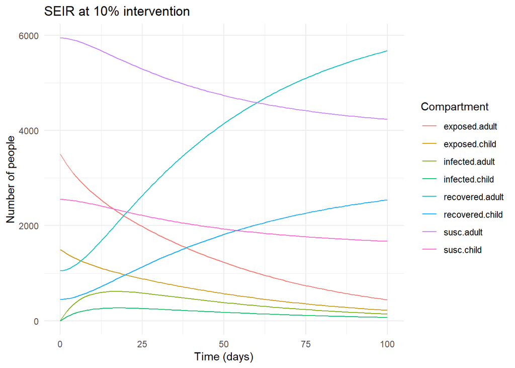

```r
ggplot(data = seir_10_long,aes(x = time, y = value, colour = state, group = state)) + geom_line() + labs(colour = "Compartment",title = "SEIR at 10% intervention",x="Time (days)",y = "Number of people")+theme_minimal()
```

> At `10 %` intervention there is significant change to the population

# 20 %

#### Introducing Vaccination

**Remember** vaccination doesn’t change `exposure` and `infection`

```r
# introducing vaccination
vac.2 = inter.2 * N
# child intervention introduced
vac.child = child.perc * vac.2
s.V.child = s.child - vac.child
e.v.child = e.child
i.v.child = i.child
r.v.child = r.child + vac.child
# adult intervention introduced
vac.adult = adult.perc * vac.2
s.v.adult = s.adult - vac.adult
e.v.adult = e.adult
i.v.adult = i.adult
r.v.adult = r.adult + vac.adult
```

## Generating Output

```r
seir_20_out = as.data.frame(lsoda(initial_state,time,seir.func,parameters))
seir_20_out
```

```
##     time        1        2         3         4         5        6         7
## 1      0 2549.700 5949.300 1500.0000 3500.0000   0.30000   0.7000  450.0000
## 2      1 2548.153 5946.246 1452.3537 3388.2763  46.49205 108.4754  453.0012
## 3      2 2543.861 5937.771 1408.9682 3285.5443  85.83316 200.2331  461.3377
## 4      3 2537.246 5924.708 1369.2882 3190.6899 119.25268 278.1185  474.2129
## 5      4 2528.679 5907.789 1332.8281 3102.7371 147.55466 343.9928  490.9379
## 6      5 2518.483 5887.648 1299.1649 3020.8335 171.43439 399.4695  510.9175
## 7      6 2506.939 5864.842 1267.9308 2944.2364 191.49311 445.9479  533.6374
## 8      7 2494.289 5839.848 1238.8073 2872.3000 208.25070 484.6409  558.6533
## 9      8 2480.743 5813.082 1211.5189 2804.4635 222.15671 516.6002  585.5813
## 10     9 2466.483 5784.903 1185.8277 2740.2409 233.59976 542.7376  614.0899
## 11    10 2451.662 5755.616 1161.5290 2679.2113 242.91597 563.8435  643.8927
## 12    11 2436.415 5725.487 1138.4463 2621.0107 250.39599 580.6032  674.7424
## 13    12 2420.855 5694.741 1116.4282 2565.3243 256.29121 593.6109  706.4257
## 14    13 2405.078 5663.571 1095.3446 2511.8801 260.81905 603.3818  738.7583
```

[output cut: 189 more lines]

```r
colnames(seir_20_out) = c("time","susc.child", "susc.adult","exposed.child", "exposed.adult", "infected.child", "infected.adult","recovered.child", "recovered.adult")
```

### converting to long format

```r
seir_20_long = seir_20_out %>% pivot_longer(cols = c("susc.child", "susc.adult","exposed.child", "exposed.adult", "infected.child", "infected.adult","recovered.child", "recovered.adult"),names_to = "state",values_to = "value" )
seir_20_long
```

```
## # A tibble: 808 × 3
##     time state            value
##    <dbl> <chr>            <dbl>
##  1     0 susc.child      2550.
##  2     0 susc.adult      5949.
##  3     0 exposed.child   1500
##  4     0 exposed.adult   3500
##  5     0 infected.child     0.3
##  6     0 infected.adult     0.7
##  7     0 recovered.child  450
##  8     0 recovered.adult 1050
##  9     1 susc.child      2548.
## 10     1 susc.adult      5946.
## # ℹ 798 more rows
```

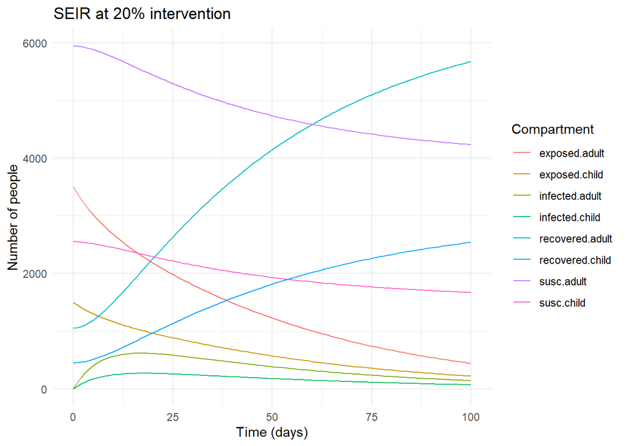

```r
ggplot(data = seir_20_long,aes(x = time, y = value, colour = state, group = state)) + geom_line() + labs(colour = "Compartment",title = "SEIR at 20% intervention",x="Time (days)",y = "Number of people")+theme_minimal()
```

> Adult recovery has a steeper curve than child recovery from `day 12` as illustrated in the low infection rates.

> The exposed adults reduce in an almost `log` rate

# 30 %

#### Introducing Vaccination

**Remember** vaccination doesn’t change `exposure` and `infection`

```r
# introducing vaccination
vac.3 = inter.3 * N
# child intervention introduced
vac.child = child.perc * vac.3
s.V.child = s.child - vac.child
e.v.child = e.child
i.v.child = i.child
r.v.child = r.child + vac.child
# adult intervention introduced
vac.adult = adult.perc * vac.3
s.v.adult = s.adult - vac.adult
e.v.adult = e.adult
i.v.adult = i.adult
r.v.adult = r.adult + vac.adult
```

## Generating Output

```r
seir_30_out = as.data.frame(lsoda(initial_state,time,seir.func,parameters))
seir_30_out
```

```
##     time        1        2         3         4         5        6         7
## 1      0 2549.700 5949.300 1500.0000 3500.0000   0.30000   0.7000  450.0000
## 2      1 2548.153 5946.246 1452.3537 3388.2763  46.49205 108.4754  453.0012
## 3      2 2543.861 5937.771 1408.9682 3285.5443  85.83316 200.2331  461.3377
## 4      3 2537.246 5924.708 1369.2882 3190.6899 119.25268 278.1185  474.2129
## 5      4 2528.679 5907.789 1332.8281 3102.7371 147.55466 343.9928  490.9379
## 6      5 2518.483 5887.648 1299.1649 3020.8335 171.43439 399.4695  510.9175
## 7      6 2506.939 5864.842 1267.9308 2944.2364 191.49311 445.9479  533.6374
## 8      7 2494.289 5839.848 1238.8073 2872.3000 208.25070 484.6409  558.6533
## 9      8 2480.743 5813.082 1211.5189 2804.4635 222.15671 516.6002  585.5813
## 10     9 2466.483 5784.903 1185.8277 2740.2409 233.59976 542.7376  614.0899
## 11    10 2451.662 5755.616 1161.5290 2679.2113 242.91597 563.8435  643.8927
## 12    11 2436.415 5725.487 1138.4463 2621.0107 250.39599 580.6032  674.7424
## 13    12 2420.855 5694.741 1116.4282 2565.3243 256.29121 593.6109  706.4257
## 14    13 2405.078 5663.571 1095.3446 2511.8801 260.81905 603.3818  738.7583
```

[output cut: 189 more lines]

```r
colnames(seir_30_out) = c("time","susc.child", "susc.adult","exposed.child", "exposed.adult", "infected.child", "infected.adult","recovered.child", "recovered.adult")
```

### converting to long format

```r
seir_30_long = seir_30_out %>% pivot_longer(cols = c("susc.child", "susc.adult","exposed.child", "exposed.adult", "infected.child", "infected.adult","recovered.child", "recovered.adult"),names_to = "state",values_to = "value" )
seir_30_long
```

```
## # A tibble: 808 × 3
##     time state            value
##    <dbl> <chr>            <dbl>
##  1     0 susc.child      2550.
##  2     0 susc.adult      5949.
##  3     0 exposed.child   1500
##  4     0 exposed.adult   3500
##  5     0 infected.child     0.3
##  6     0 infected.adult     0.7
##  7     0 recovered.child  450
##  8     0 recovered.adult 1050
##  9     1 susc.child      2548.
## 10     1 susc.adult      5946.
## # ℹ 798 more rows
```

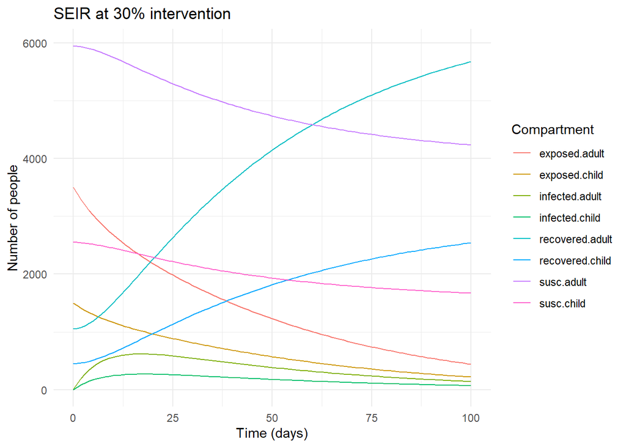

```r
ggplot(data = seir_30_long,aes(x = time, y = value, colour = state, group = state)) + geom_line() + labs(colour = "Compartment",title = "SEIR at 30% intervention",x="Time (days)",y = "Number of people")+theme_minimal()
```

# 50 %

#### Introducing Vaccination

**Remember** vaccination doesn’t change `exposure` and `infection`

```r
# introducing vaccination
vac.5 = inter.5 * N
# child intervention introduced
vac.child = child.perc * vac.5
s.V.child = s.child - vac.child
e.v.child = e.child
i.v.child = i.child
r.v.child = r.child + vac.child
# adult intervention introduced
vac.adult = adult.perc * vac.5
s.v.adult = s.adult - vac.adult
e.v.adult = e.adult
i.v.adult = i.adult
r.v.adult = r.adult + vac.adult
```

## Generating Output

```r
seir_50_out = as.data.frame(lsoda(initial_state,time,seir.func,parameters))
seir_50_out
```

```
##     time        1        2         3         4         5        6         7
## 1      0 2549.700 5949.300 1500.0000 3500.0000   0.30000   0.7000  450.0000
## 2      1 2548.153 5946.246 1452.3537 3388.2763  46.49205 108.4754  453.0012
## 3      2 2543.861 5937.771 1408.9682 3285.5443  85.83316 200.2331  461.3377
## 4      3 2537.246 5924.708 1369.2882 3190.6899 119.25268 278.1185  474.2129
## 5      4 2528.679 5907.789 1332.8281 3102.7371 147.55466 343.9928  490.9379
## 6      5 2518.483 5887.648 1299.1649 3020.8335 171.43439 399.4695  510.9175
## 7      6 2506.939 5864.842 1267.9308 2944.2364 191.49311 445.9479  533.6374
## 8      7 2494.289 5839.848 1238.8073 2872.3000 208.25070 484.6409  558.6533
## 9      8 2480.743 5813.082 1211.5189 2804.4635 222.15671 516.6002  585.5813
## 10     9 2466.483 5784.903 1185.8277 2740.2409 233.59976 542.7376  614.0899
## 11    10 2451.662 5755.616 1161.5290 2679.2113 242.91597 563.8435  643.8927
## 12    11 2436.415 5725.487 1138.4463 2621.0107 250.39599 580.6032  674.7424
## 13    12 2420.855 5694.741 1116.4282 2565.3243 256.29121 593.6109  706.4257
## 14    13 2405.078 5663.571 1095.3446 2511.8801 260.81905 603.3818  738.7583
```

[output cut: 189 more lines]

```r
colnames(seir_50_out) = c("time","susc.child", "susc.adult","exposed.child", "exposed.adult", "infected.child", "infected.adult","recovered.child", "recovered.adult")
```

### converting to long format

```r
seir_50_long = seir_50_out %>% pivot_longer(cols = c("susc.child", "susc.adult","exposed.child", "exposed.adult", "infected.child", "infected.adult","recovered.child", "recovered.adult"),names_to = "state",values_to = "value" )
seir_50_long
```

```
## # A tibble: 808 × 3
##     time state            value
##    <dbl> <chr>            <dbl>
##  1     0 susc.child      2550.
##  2     0 susc.adult      5949.
##  3     0 exposed.child   1500
##  4     0 exposed.adult   3500
##  5     0 infected.child     0.3
##  6     0 infected.adult     0.7
##  7     0 recovered.child  450
##  8     0 recovered.adult 1050
##  9     1 susc.child      2548.
## 10     1 susc.adult      5946.
## # ℹ 798 more rows
```

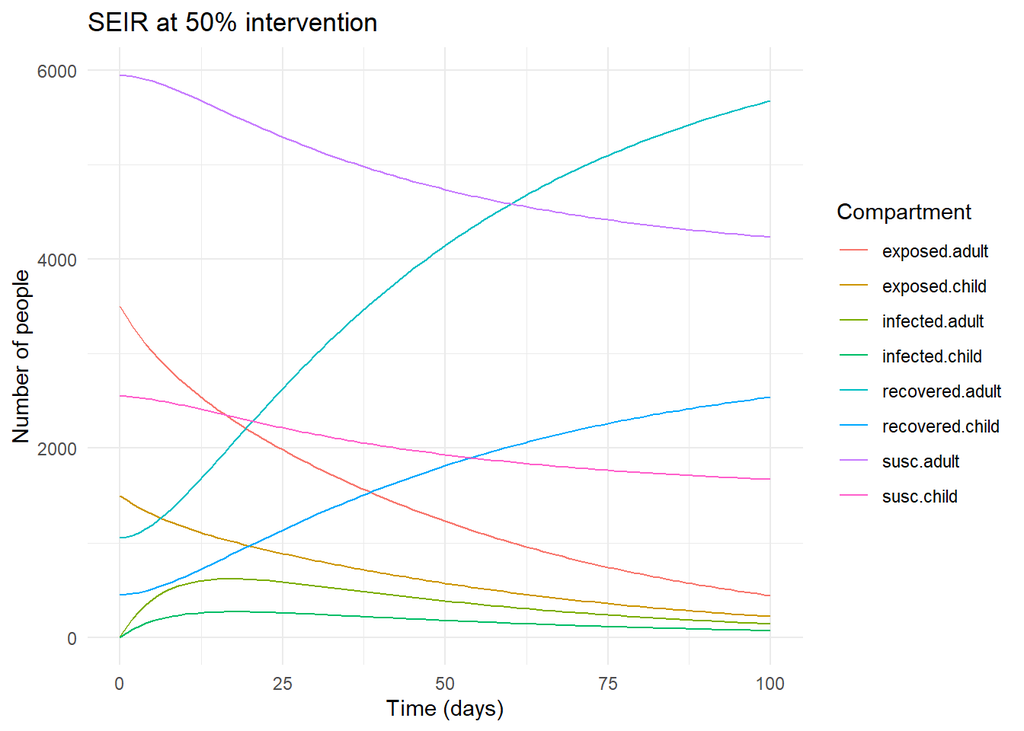

```r
ggplot(data = seir_50_long,aes(x = time, y = value, colour = state, group = state)) + geom_line() + labs(colour = "Compartment",title = "SEIR at 50% intervention",x="Time (days)",y = "Number of people")+theme_minimal()
```

> Adult recovery has a steeper curve than child recovery from `day 12` as illustrated in the low infection rates.

> The exposed adults reduce in an almost `log` rate